# Inference for to Linear Regression - Key

Dr. Theobold

The Human Freedom Index is a report that attempts to summarize the idea of “freedom” through a bunch of different variables for many countries around the globe. It serves as a rough objective measure for the relationships between the different types of freedom - whether it’s political, religious, economical or personal freedom - and other social and economic circumstances. The Human Freedom Index is an annually co-published report by the Cato Institute, the Fraser Institute, and the Liberales Institut at the Friedrich Naumann Foundation for Freedom.

In this lab, you’ll be analyzing data from Human Freedom Index reports from 2008-2016. Your aim will be to summarize a few of the relationships within the data both graphically and numerically in order to discuss how different variables can help tell a story about freedom.

# Getting Started

## Load Packages

In this lab, you will explore and visualize the data using the **tidyverse** suite of packages.

You will also use the **moderndive** package to get nice looking regression tables.

The data can be found in the **openintro** package.

Let’s load the packages!

```r
library(tidyverse)
library(moderndive)
library(openintro)
library(infer)
```

# The data

The data we’re working with is in the openintro package and it’s called `hfi`, short for Human Freedom Index.

**1. The dataset has **a lot** of variables, but we are only interested in four: hf_score, pf_score, year, and region. *Select* these variables from the hfi dataframe, and assign the result to a dataframe named hfi_small.**

```r
## Fill in the code necessary for question 2

hfi_small <- hfi %>%
  select(pf_score, hf_score, year, region)
```

**4** – Uses `select()` to include only the listed variables

**Redo** – Otherwise

We can use the `drop_na()` function to get an idea of how many observations have missing data. The function looks row by row through the data to decide what rows should be kept. If there is an `NA` value in a row, that row is discarded. The result is a dataframe where there are no missing values for any of the variables.

**2. Use the drop_na() function to create another new dataframe named hfi_small_clean that **does not** contain any missing values.**

```r
hfi_small_clean <- drop_na(hfi_small)
```

**4** – Uses `drop_na()` to remove the missing observations from the `hfi_small` dataset

**Redo** – Otherwise

# Visualizing the Relationship Between Human Freedom and Personal Freedom

**3. (a) Plot the relationship between `pf_score` (x) and `hf_score` (y), including a linear regression line.**

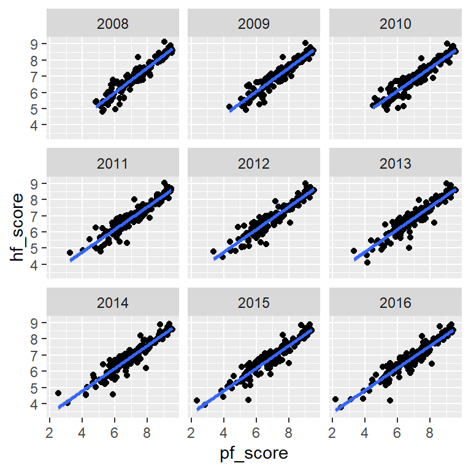

```r
## Code for question 4
hfi_small_clean %>%
  ggplot(mapping = aes(y = hf_score, x = pf_score)) +
  geom_jitter() +
  geom_smooth(method = "lm") +
  facet_wrap(~year)
```

**4** – Has all of the following:

- `hf_score` on y-axis
- `pf_score` on x-axis
- points with either `geom_point()` or `geom_jitter()`
- `geom_smooth(method = "lm")` line added

**3** – Has all of the above except for a regression line

**Redo** – Otherwise

**3. (b) Does the relationship look linear? How strong is the relationship?** Hint: This is a great instance to use `geom_jitter()`!

*The relationship appears linear, and is fairly strong!*

**4** – states something similar to above

**Redo** – if does not state the relationship appears linear

**4. Now, add a facet for each year in the dataset. Does it appear that this relationship changes over time?**

*It looks like the overall trend is similar across the years, but some years have more variability in these scores than others. For example, 2008 is fairly tightly clustered around the regression line, but 2016 has a bit more variability in lower personal freedom scores.*

**4** – Has all of the following:

- adds a `facet_wrap(~year)` to the previous code
- states that the trend looks similar across the years
- talks about differences in variability across the years

**3** – Meets the above criteria but **does not** discuss variability

**Redo** – Otherwise

# Modeling the Relationship Between Human Freedom and Personal Freedom

Our statistical method will be driven by the conditions for our linear regression.

## Checking Conditions

You’ve already discussed the *linear relationship* condition, so let’s move on to the independence condition.

**5. Given that we’re accounting for year, do you believe it is reasonable to assume these observations are independent? Why or why not?**

*There could still be some geographical similarities that have not been accounted for. For example, the European Union has regulatory measures that could make the observations of countries share information.*

```r
pf_lm <- lm(hf_score ~ pf_score * year , data = hfi)
```

**4** – Has interaction (`pf_score * year`) as explanatory variables

**Redo** – Otherwise

Next, you’ll use the code below to diagnose the *normality* and *equal variance* conditions.

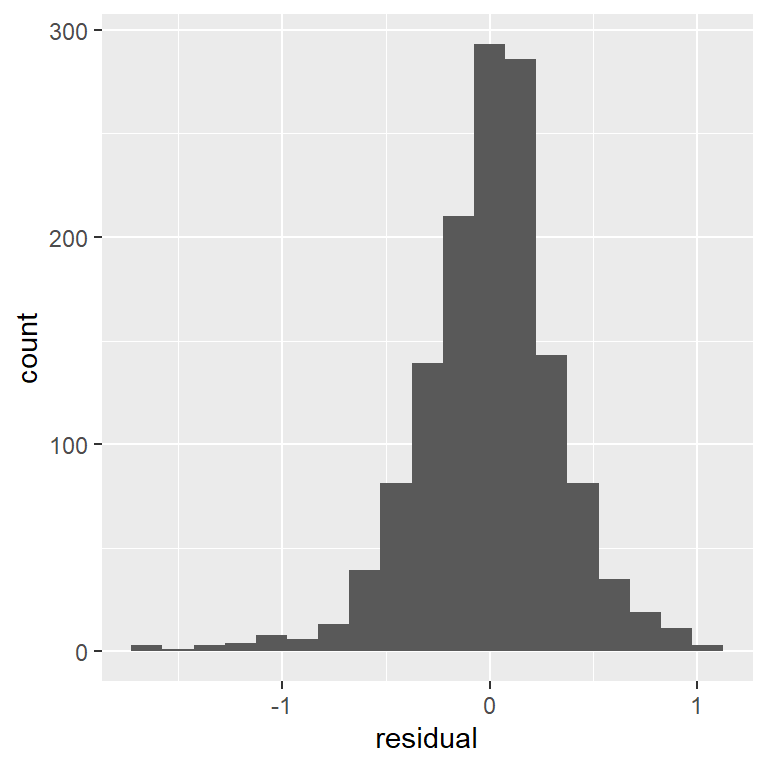

```r
get_regression_points(pf_lm) %>%
  ggplot(mapping = aes(x = residual)) +
  geom_histogram(binwidth = 0.15)
```

**7. Based on the plot above, do you believe the normality condition is violated? Why or why not?**

*I would not say that this condition is violated. It appears that the distribution of the residuals is centered at 0 and bell-shaped and symmetric.*

**4** – Has the following:

- Condition is not violated
- Distribution appears symmetric
- Distribution is centered at 0
- References long left tail but decides it’s not too bad

**3** – Meets all of the above criteria but does not discuss the left tail

**Redo** – Otherwise

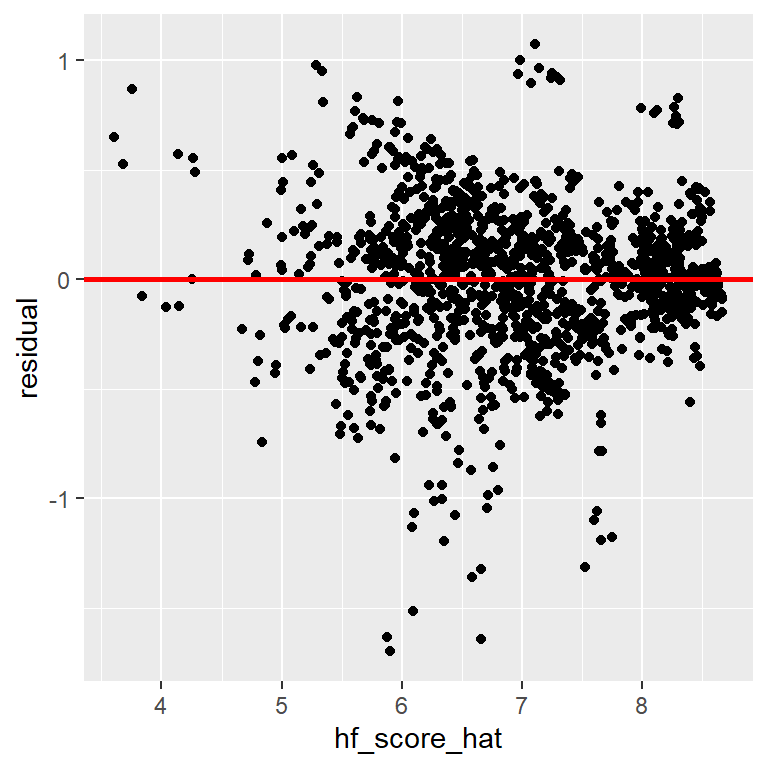

```r
get_regression_points(pf_lm) %>%
  ggplot(mapping = aes(y = residual, x = hf_score_hat)) +
  geom_jitter() +
  geom_hline(yintercept = 0, color = "red", size = 1)
```

**8. Based on the plot above, do you believe the equal variance condition is violated? Why or why not?**

*While the plot does not look great, I don’t see any major issues. The residuals are fairly small, ranging from -1 to 1, across the majority of the regression line (in red). There may be slightly less variability in the larger values of human freedom scores (hf_score_hat), but not enough to warrant concerns.*

**4** – Has the following:

- Discusses size of residuals ranging from -1 to 1
- Mentions how values on the left and on the right have smaller residuals than the middle
- Decides that the condition is not violated

**3** – Has all of the above but does not mention the size of the residuals

**Redo** – Otherwise

## Hypothesis Test for the Slope

First, we will carry out a hypothesis test to investigate if the relationship between hf_score and pf_score differs by year. This entails that we are first testing to see if we need the interaction term in our multiple linear regression. These hypotheses are a bit different than before, so let’s walk through them.

To test if an interaction term is needed, we are testing if the slope on pf_score should change based on the year. For a quantitative variable, this is either a “yes” or “no” answer. The hypotheses look like the following:

H_0: the true relationship between x and y *does not* differ by z

H_A: the true relationship between x and y *does* differ by z

**9. Using the template above, write out the null and alternative hypotheses we are testing, in the context of these data.**

*H_0: the relationship between human freedom score and personal freedom does not differ by year*

*H_A: the relationship between human freedom score and personal freedom does differ by year*

**Redo** – Otherwise

**10. Report the p-value for this hypothesis test. What would you conclude for this test?**  
Hint 1: Deciding to reject or not **is not** a conclusion, you need to specify which hypothesis seems more plausible **and** what that means in the context of these data!  
Hint 2: Stating you reject the null hypothesis requires that you specify an $\alpha$ that was used. Hint 3: There should be no use of the term “significant” in your conclusion.

**Redo** – Otherwise

```r
## Code for finding the p-value goes below this line!

get_regression_table(pf_lm)
```

```
## # A tibble: 4 x 7
##   term          estimate std_error statistic p_value lower_ci upper_ci
##   <chr>            <dbl>     <dbl>     <dbl>   <dbl>    <dbl>    <dbl>
## 1 intercept     -117.       38.6       -3.04   0.002 -193.     -41.4
## 2 pf_score        13.2       5.25       2.52   0.012    2.92    23.5
## 3 year             0.059     0.019      3.09   0.002    0.022    0.097
## 4 pf_score:year   -0.006     0.003     -2.38   0.017   -0.011   -0.001
```

**11. How would you interpret this interaction term?** **Give this your best shot! I will be grading based on the ideas you present.** **See if you can make connections between this coefficient and what you saw with a categorical explanatory variable.**

*The interaction is interpreted as adjusting the slope based on the year of the observation. The data has years from 2008 to 2016, and year is considered as a continuous numerical variable. So, we would plug in the year and obtain the amount we need to adjust the slope by.*

*We notice that the interaction is negative, meaning we are always adjusting our slope down from the “baseline”. For 2008, we would decrease the slope by $2008 \times -0.006 = 12.048$, resulting in a slope on pf_score of $13.2 - 12.048 = 1.152$. For 2016, we would decrease the slope by $2016 \times -0.006 = 12.096$, resulting in a slope on pf_score of $13.2 - 12.096 = 1.104.$*

**4** – Has the following:

- Talks about how year is continuous
- Talks about how year is used to adjust the slope on `pf_score`
- References how the slope being negative means the later years have smaller slopes than the earlier years

**3** – Has the first two components from above, but doesn’t connect the negative coefficient to smaller slopes for later years

**Redo** – Otherwise